# Neighbor2Neighbor Program Evlauation

## Interpretation

Overall, we’re again seeing about a 2.5 percentage point increase in probability of voting for voters that were successfully contacted vs those that were in the treatment group but not contacted. In addition, we’re again doing a considerably better job predicting voting behavior if we include canvassing results in our model than we would do if we excluded that term.

# Analysis 3: Contacted vs. Not Home

For this third analysis, I estimated the effect of voter contact relative to the *attempted but not home* group (those with `treatment == 1` & `canvass_result == “NOT_HOME”`). Because canvassers attempted to approach the houses represented in both of these groups, they may be expected to differ less geographically and in terms of external characteristics. However, these groups could differ systematically for other reasons (e.g. residents’ willingness to come to the door to talk to a stranger, work-from-home status, etc).

## Analysis data creation

```r
adat3 =
  dat %>%
  mutate(z_age = scale(age),
         z_turnout_score = scale(turnout_score),
         z_partisan_score = scale(partisan_score)) %>%
  group_by(canvasser_id) %>%
  mutate(n_assignment_ids = length(unique(assignment_id))) %>%
  ungroup() %>%
  mutate(mult_assign_ids = n_assignment_ids > 1) %>%
  filter(age >= 18,
         partisan_score > 60, # excluding small number of voters with low partisanship scores (only 5 were assigned to treatment)
         canvass_result != "NOT_VISITED", # excluding this group for now
         canvass_result != "OPPOSITION_VOTER" # very few of these in sample
         ) %>%  # excluding for now, worth comparing
  mutate(canvass_result2 = factor(canvass_result),
         race2 = factor(race),
         urbanicity2 = factor(urbanicity))
```

## Model results

For full modeling procedure, including testing whether model expectations are met, please see the `analysis.R` file. I’m just showing the results here:

### 1. Model fit with and without canvass result term

First, let’s compare model fit of `mmm2`, the model that includes the `canvass_result` term, and `mmm3`, the same model without that term. The model with the lower AICc score (corrected Akaike’s Information Criterion) has better support.

```r
AICc(mmm2, mmm3)
```

|  | df | AICc |
| --- | --- | --- |
| mmm2 | 15 | 13470.57 |
| mmm3 | 14 | 13486.47 |

So again, the model that includes the `canvass_result` term fits considerably better than the one without.

### 2. Model results table

Here are the results of the best-supported model for predicting likelihood of voting:

```r
tab_model(mmm2)
```

|  | voted |  |  |
| --- | --- | --- | --- |
| Predictors | Odds Ratios | CI | p |
| (Intercept) | 3.07 | 2.52 – 3.75 | **<0.001** |
| canvass result2 [SPOKE_TO] | 1.21 | 1.11 – 1.32 | **<0.001** |
| z turnout score | 3.37 | 3.21 – 3.54 | **<0.001** |
| z partisan score | 1.13 | 1.08 – 1.18 | **<0.001** |
| z age [1st degree] | 23.39 | 0.09 – 6081.65 | 0.267 |
| z age [2nd degree] | 0.00 | 0.00 – 0.00 | **<0.001** |
| urbanicity2 [suburban] | 1.03 | 0.89 – 1.18 | 0.720 |
| urbanicity2 [urban] | 1.03 | 0.89 – 1.18 | 0.721 |
| race2 [ASIAN] | 1.09 | 0.90 – 1.33 | 0.382 |
| race2 [HISPANIC] | 1.15 | 0.95 – 1.38 | 0.151 |
| race2 [NATIVE] | 0.76 | 0.20 – 2.88 | 0.684 |
| race2 [UNK] | 1.59 | 1.29 – 1.96 | **<0.001** |
| race2 [WHITE] | 1.40 | 1.22 – 1.60 | **<0.001** |
| n assignment ids | 0.99 | 0.98 – 1.00 | **0.002** |
| Random Effects |  |  |  |
| σ<sup>2</sup> | 3.29 |  |  |
| τ<sub>00</sub> <sub>state</sub> | 0.04 |  |  |
| ICC | 0.01 |  |  |
| N <sub>state</sub> | 24 |  |  |
| Observations | 16273 |  |  |
| Marginal R<sup>2</sup> / Conditional R<sup>2</sup> | 0.342 / 0.350 |  |  |

Here we see that, all else equal, a voter who was spoken to by a canvasser was 21% increase in odds of voting relative to someone whose house was approached but they weren’t home.

### 3. Model-predicted voting rates

Finally, we can get a measure of predicted probability of voting in these two groups:

```
## Model contains splines or polynomial terms. Consider using
##   `terms="canvass_result2 [all]"` to get smooth plots. See also
##   package-vignette 'Adjusted Predictions at Specific Values'.
```

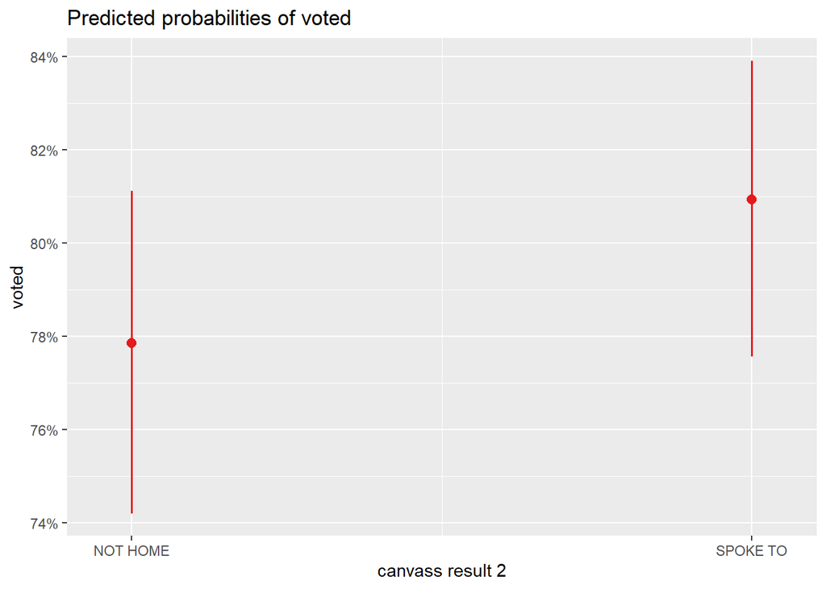

```r
plot_model(mmm2, type = "pred", terms = "canvass_result2")
```

Other results are remain consistent.

## Interpretation

# Overall summary

Despite the potential biases in the sample, results remain remarkably consistent across our three comparisons. Voters with whom a volunteer spoke had between a 2.5 and 3 percentage point increase in ther probability of voting relative to those in the control group, those who were assigned to the treatment group but never contacted, and those whose houses were approached but were not home. The concordance between these analyses suggests that this effect is robust to model specification and sources of sampling bias.

Not assessed here was the overall effect of the program as implemented to date. With more time, I’d like to also estimate the effect of the program on voting behavior.

But based on this analysis, it appears that voter contact through the Neighbor2Neighbor program has consistently positive effecs on voter turnout.

# Recommendations

- Given that 1) speaking to voters appears to have a consistent positive association with voting rates, but 2) the majority of households in the “treatment” group were coded as not contacted, focus should be given to how to optimize contact success rates for canvassers.
- Scaling may be complicated; I was surprised that the volunteers with the most assignments had lower rates of voter turnout. If this effect is to be believed, maybe efforts could focus more on activating first-time canvassers than on encouraging repeat canvassing assignments (although the latter should not be discouraged).
- A follow-up analysis with additional data could be helpful for further optimizing the program: for example, what are the effects of time of day on likelihood of voter contact or (if voter contact is made) voting behavior? Most people probably don’t want to canvas after 5 pm, but would that improve the likelihood of speaking to voters in the household?
- What about the effect of race of the canvasser, or whether the canvasser and voter were the same race, on voter turnout?